# **Normalization** strategy comparison for **Data-driven** analysis of isobarically labeled proteomic data.

Joris Van Houtven, Piotr Prostko

November 08, 2022,18:51

*This notebook is one in a series of many, where we explore how different data analysis strategies affect the outcome of a proteomics experiment based on isobaric labeling and mass spectrometry. Each analysis strategy or ‘workflow’ can be divided up into different components; it is recommend you read more about that in the introduction notebook.*

In this notebook specifically, we investigate the effect of varying the **Normalization** component on the outcome of the differential expression results. The five component variants are: **median sweeping**, **CONSTANd**, **NOMAD**, **quantile1 (first on PSM level)**, **quantile2 (only on protein level)**.

*The R packages and helper scripts necessary to run this notebook are listed in the next code chunk: click the ‘Code’ button. Each code section can be expanded in a similar fashion. You can also download the entire notebook source code.*

```r
library(stringi)
library(gridExtra)
library(dendextend)
library(kableExtra)
library(psych)
library(limma)
library(tidyverse)
library(preprocessCore)
library(CONSTANd)
library(NOMAD)  # devtools::install_github("carlmurie/NOMAD")
source('util/other_functions.R')
source('util/plotting_functions.R')
```

Let’s load our PSM-level data set:

```r
data.list <- readRDS(params$input_data_p)
dat.l <- data.list$dat.l # data in long format
display_dataframe_head(dat.l)
```

| Mixture | TechRepMixture | Condition | BioReplicate | Run | Channel | Protein | Peptide | RT | Charge | PTM | intensity | TotalIntensity | Ions.Score | DeltaMZ | isoInterOk | noNAs | onehit.protein | shared.peptide |
| --- | --- | --- | --- | --- | --- | --- | --- | --- | --- | --- | --- | --- | --- | --- | --- | --- | --- | --- |
| Mixture2 | 1 | 1 | Mixture2_1 | Mixture2_1 | 127C | P21291 | [K].gFGFGQGAGALVHSE.[-] | 144.9444 | 2 | N-Term(TMT6plex) | 44048.41 | 394657.6 | 65 | 0.00052 | TRUE | TRUE | FALSE | FALSE |
| Mixture2 | 1 | 0.5 | Mixture2_0.5 | Mixture2_1 | 127N | P21291 | [K].gFGFGQGAGALVHSE.[-] | 144.9444 | 2 | N-Term(TMT6plex) | 38298.89 | 394657.6 | 65 | 0.00052 | TRUE | TRUE | FALSE | FALSE |
| Mixture2 | 1 | 0.125 | Mixture2_0.125 | Mixture2_1 | 128C | P21291 | [K].gFGFGQGAGALVHSE.[-] | 144.9444 | 2 | N-Term(TMT6plex) | 39552.81 | 394657.6 | 65 | 0.00052 | TRUE | TRUE | FALSE | FALSE |
| Mixture2 | 1 | 0.667 | Mixture2_0.667 | Mixture2_1 | 128N | P21291 | [K].gFGFGQGAGALVHSE.[-] | 144.9444 | 2 | N-Term(TMT6plex) | 56730.70 | 394657.6 | 65 | 0.00052 | TRUE | TRUE | FALSE | FALSE |
| Mixture2 | 1 | 0.667 | Mixture2_0.667 | Mixture2_1 | 129C | P21291 | [K].gFGFGQGAGALVHSE.[-] | 144.9444 | 2 | N-Term(TMT6plex) | 48744.49 | 394657.6 | 65 | 0.00052 | TRUE | TRUE | FALSE | FALSE |
| Mixture2 | 1 | 1 | Mixture2_1 | Mixture2_1 | 129N | P21291 | [K].gFGFGQGAGALVHSE.[-] | 144.9444 | 2 | N-Term(TMT6plex) | 60179.96 | 394657.6 | 65 | 0.00052 | TRUE | TRUE | FALSE | FALSE |

After the filtering done in `data_prep.R`, there are 19 UPS1 proteins remaining, even though 48 were originally spiked in.

```r
# which proteins were spiked in?
spiked.proteins <- dat.l %>% distinct(Protein) %>% filter(stri_detect(Protein, fixed='ups')) %>% pull %>% as.character
remove_factors(spiked.proteins)
```

```
##  [1] "P02787ups"   "P02788ups"   "P01133ups"   "P69905ups"   "P01008ups"   "P02741ups"   "P01375ups"
##  [8] "P10636-8ups" "O00762ups"   "P62988ups"   "P10145ups"   "P05413ups"   "P00915ups"   "P02753ups"
## [15] "P02144ups"   "P01344ups"   "P01579ups"   "P00709ups"   "P01127ups"
```

```r
tmp=dat.l %>% distinct(Protein) %>% pull %>% as.character
# protein subsampling
if (params$subsample_p>0 & params$subsample_p==floor(params$subsample_p) & params$subsample_p<=length(tmp)){
  sub.prot <- tmp[sample(1:length(tmp), size=params$subsample_p)]
  if (length(spiked.proteins)>0) sub.prot <- c(sub.prot,spiked.proteins)
  dat.l <- dat.l %>% filter(Protein %in% sub.prot)
}
```

We store the metadata in `sample.info` and show some entries below. We also pick technical replicates with a dilution factor of 0.5 as the reference condition of interest. Each condition is represented by two of eight reporter Channels in each Run.

```r
display_dataframe_head(sample.info)
```

| Run | Run.short | Channel | Sample | Sample.short | Condition | Color |
| --- | --- | --- | --- | --- | --- | --- |
| Mixture1_1 | Mix1_1 | 127C | Mixture1_1:127C | Mix1_1:127C | 0.125 | black |
| Mixture1_1 | Mix1_1 | 127N | Mixture1_1:127N | Mix1_1:127N | 0.667 | green |
| Mixture1_1 | Mix1_1 | 128C | Mixture1_1:128C | Mix1_1:128C | 1 | red |
| Mixture1_1 | Mix1_1 | 128N | Mixture1_1:128N | Mix1_1:128N | 0.5 | blue |
| Mixture1_1 | Mix1_1 | 129C | Mixture1_1:129C | Mix1_1:129C | 0.5 | blue |
| Mixture1_1 | Mix1_1 | 129N | Mixture1_1:129N | Mix1_1:129N | 0.125 | black |

```r
referenceCondition
```

```
## [1] "0.5"
```

```r
channelNames
```

```
## [1] "127C" "127N" "128C" "128N" "129C" "129N" "130C" "130N"
```

# 1 Unit scale component: log2 transformation of reporter ion intensities

We use the default unit scale: the log2-transformed reportion ion intensities.

```r
dat.unit.l <- dat.l %>% mutate(response=log2(intensity)) %>% select(-intensity)
display_dataframe_head(dat.unit.l)
```

| Mixture | TechRepMixture | Condition | BioReplicate | Run | Channel | Protein | Peptide | RT | Charge | PTM | TotalIntensity | Ions.Score | DeltaMZ | isoInterOk | noNAs | onehit.protein | shared.peptide | response |
| --- | --- | --- | --- | --- | --- | --- | --- | --- | --- | --- | --- | --- | --- | --- | --- | --- | --- | --- |
| Mixture2 | 1 | 1 | Mixture2_1 | Mixture2_1 | 127C | P21291 | [K].gFGFGQGAGALVHSE.[-] | 144.9444 | 2 | N-Term(TMT6plex) | 394657.6 | 65 | 0.00052 | TRUE | TRUE | FALSE | FALSE | 15.42680 |
| Mixture2 | 1 | 0.5 | Mixture2_0.5 | Mixture2_1 | 127N | P21291 | [K].gFGFGQGAGALVHSE.[-] | 144.9444 | 2 | N-Term(TMT6plex) | 394657.6 | 65 | 0.00052 | TRUE | TRUE | FALSE | FALSE | 15.22502 |
| Mixture2 | 1 | 0.125 | Mixture2_0.125 | Mixture2_1 | 128C | P21291 | [K].gFGFGQGAGALVHSE.[-] | 144.9444 | 2 | N-Term(TMT6plex) | 394657.6 | 65 | 0.00052 | TRUE | TRUE | FALSE | FALSE | 15.27149 |
| Mixture2 | 1 | 0.667 | Mixture2_0.667 | Mixture2_1 | 128N | P21291 | [K].gFGFGQGAGALVHSE.[-] | 144.9444 | 2 | N-Term(TMT6plex) | 394657.6 | 65 | 0.00052 | TRUE | TRUE | FALSE | FALSE | 15.79184 |
| Mixture2 | 1 | 0.667 | Mixture2_0.667 | Mixture2_1 | 129C | P21291 | [K].gFGFGQGAGALVHSE.[-] | 144.9444 | 2 | N-Term(TMT6plex) | 394657.6 | 65 | 0.00052 | TRUE | TRUE | FALSE | FALSE | 15.57295 |
| Mixture2 | 1 | 1 | Mixture2_1 | Mixture2_1 | 129N | P21291 | [K].gFGFGQGAGALVHSE.[-] | 144.9444 | 2 | N-Term(TMT6plex) | 394657.6 | 65 | 0.00052 | TRUE | TRUE | FALSE | FALSE | 15.87700 |

# 2 Normalization component

Since these methods all need to be applied on matrix-like data, let’s switch to wide format. (Actually, this is semi-wide, since the Channel columns still have contributions form all Runs, but that’s OK because in the next step we split by Run.)

```r
# switch to wide format
dat.unit.w <- pivot_wider(data = dat.unit.l, id_cols=-one_of(c('Condition', 'BioReplicate')), names_from=Channel, values_from=response)
display_dataframe_head(dat.unit.w)
```

| Mixture | TechRepMixture | Run | Protein | Peptide | RT | Charge | PTM | TotalIntensity | Ions.Score | DeltaMZ | isoInterOk | noNAs | onehit.protein | shared.peptide | 127C | 127N | 128C | 128N | 129C | 129N | 130C | 130N |
| --- | --- | --- | --- | --- | --- | --- | --- | --- | --- | --- | --- | --- | --- | --- | --- | --- | --- | --- | --- | --- | --- | --- |
| Mixture2 | 1 | Mixture2_1 | P21291 | [K].gFGFGQGAGALVHSE.[-] | 144.9444 | 2 | N-Term(TMT6plex) | 394657.56 | 65 | 0.00052 | TRUE | TRUE | FALSE | FALSE | 15.42680 | 15.22502 | 15.27149 | 15.79184 | 15.57295 | 15.87700 | 15.71883 | 15.69836 |
| Mixture2 | 1 | Mixture2_1 | P30511 | [K].wAAVVVPPGEEQR.[Y] | 137.1704 | 2 | N-Term(TMT6plex) | 180359.11 | 27 | -0.00653 | TRUE | TRUE | TRUE | FALSE | 14.36513 | 14.14964 | 14.27690 | 14.65920 | 14.44955 | 14.58652 | 14.54510 | 14.57900 |
| Mixture2 | 1 | Mixture2_1 | P02787ups | [K].sASDLTWDNLk.[G] | 148.8299 | 3 | N-Term(TMT6plex); K11(TMT6plex) | 507218.12 | 35 | -0.00005 | TRUE | TRUE | FALSE | FALSE | 16.31046 | 15.32833 | 15.11530 | 16.27180 | 15.92615 | 16.73355 | 15.74796 | 15.42268 |
| Mixture2 | 1 | Mixture2_1 | Q9UBQ5 | [K].iDFDSVSSIMASSQ.[-] | 201.8727 | 2 | N-Term(TMT6plex) | 120944.32 | 72 | 0.00119 | TRUE | TRUE | FALSE | FALSE | 13.51956 | 13.51995 | 13.66172 | 14.36018 | 13.87050 | 14.20738 | 13.86685 | 13.83673 |
| Mixture2 | 1 | Mixture2_1 | Q5H9R7 | [R].tGQPSAPGDTSVNGPV.[-] | 106.9002 | 2 | N-Term(TMT6plex) | 99098.46 | 23 | -0.00133 | TRUE | TRUE | FALSE | FALSE | 13.54513 | 13.17495 | 13.34133 | 13.81323 | 13.58510 | 14.02262 | 13.60511 | 13.51803 |
| Mixture2 | 1 | Mixture2_1 | P43490 | [K].nAQLNIELEAAHH.[-] | 99.8437 | 3 | N-Term(TMT6plex) | 497023.17 | 15 | 0.00061 | TRUE | TRUE | FALSE | FALSE | 15.58965 | 15.43193 | 15.86127 | 16.18651 | 15.86677 | 16.28384 | 15.93733 | 16.03418 |

```r
dat.norm.w <- emptyList(variant.names)
```

## 2.1 median sweeping (1)

Median sweeping means subtracting from each PSM quantification value the spectrum median (i.e., the row median computed across samples/channels) and the sample median (i.e., the column median computed across features). If the unit scale is set to intensities or ratios, the multiplicative variant of this procedure is applied: subtraction is replaced by division. First, let’s sweep the medians of all the rows, and do the columns later as suggested by [Herbrich at al.](https://doi.org/10.1021/pr300624g). No need to split this per Run, because each row in this semi-wide format contains only values from one Run and each median calculation is independent of the other rows.

```r
# subtract the spectrum median log2intensity from the observed log2intensities
dat.norm.w$median_sweeping <- dat.unit.w
dat.norm.w$median_sweeping[,channelNames] <- median_sweep(dat.norm.w$median_sweeping[,channelNames], 1, '-')
```

## 2.2 CONSTANd

CONSTANd ([Van Houtven et al.](https://doi.org/10.1016/j.jmb.2021.166966)) normalizes a data matrix by ‘raking’ iteratively along the rows and columns (i.e. multiplying each row or column with a particular number) such that the row means and column means equal 1. One can never attain these row and column constraints simultaneously, but the algorithm converges very fast to the desired precision.

```r
# dat.unit.l entries are in long format so all have same colnames and no channelNames
x.split <- split(dat.unit.w, dat.unit.w$Run)  # apply CONSTANd to each Run separately
x.split.norm  <- lapply(x.split, function(y) {
  y[,channelNames] <- CONSTANd(y[,channelNames])$normalized_data
  return(y)
})
dat.norm.w$CONSTANd <- bind_rows(x.split.norm)
display_dataframe_head(dat.norm.w$CONSTANd[, channelNames])
```

| 127C | 127N | 128C | 128N | 129C | 129N | 130C | 130N |
| --- | --- | --- | --- | --- | --- | --- | --- |
| 1.0070564 | 1.0119939 | 0.9735178 | 0.9986356 | 1.0126119 | 1.0100713 | 0.9901744 | 0.9959388 |
| 0.9997616 | 0.9985738 | 0.9998317 | 1.0070210 | 0.9873465 | 0.9984853 | 0.9987635 | 1.0102166 |
| 0.9940606 | 1.0048315 | 1.0014354 | 0.9933211 | 1.0012260 | 1.0077643 | 0.9955799 | 1.0017812 |
| 1.0069406 | 1.0001663 | 0.9893311 | 0.9970276 | 0.9978282 | 0.9993591 | 0.9989784 | 1.0103687 |
| 1.0025539 | 1.0100617 | 0.9989662 | 0.9943918 | 0.9940122 | 0.9814986 | 1.0073117 | 1.0112039 |
| 0.9918683 | 0.9987713 | 1.0031477 | 0.9980860 | 0.9925122 | 1.0000085 | 1.0056106 | 1.0099954 |

## 2.3 NOMAD

NOMAD ([Murie et al.](https://doi.org/10.1016/j.jbior.2017.11.005)) is a computationally efficient implementation akin to linear regression, similar to Tukey’s median polish but using the mean: it subtracts the mean from each subset (defined by a categorical covariate) of quantification values, sequentially for each covariate. We apply NOMAD on the PSM level instead of the peptide level.

```r
# doRobust=F: use means, like CONSTANd; doLog=F: values are already transformed.
dat.nomadnorm <- nomadNormalization(dat.unit.l$response, dat.unit.l %>% rename(iTRAQ=Channel) %>% as.data.frame, doRobust = FALSE, doiTRAQCorrection = FALSE, doLog = FALSE)
```

```
## Running normalization with  464224  number of data points
## Normalizing for factor:  Peptide
## Normalizing for factor:  Run
## Normalizing for factor:  iTRAQ
## Normalizing for factor:  Run Peptide
## Normalizing for factor:  Run iTRAQ
```

```r
dat.nomadnorm$x$response <- dat.nomadnorm$y
dat.norm.w$NOMAD <- pivot_wider(data = dat.nomadnorm$x, id_cols=-one_of(c('Condition', 'BioReplicate')), names_from=iTRAQ, values_from=response)
display_dataframe_head(dat.norm.w$NOMAD[, channelNames])
```

| 127C | 127N | 128C | 128N | 129C | 129N | 130C | 130N |
| --- | --- | --- | --- | --- | --- | --- | --- |
| 0.0815099 | -0.0090445 | -0.1344888 | -0.0490965 | -0.0022344 | -0.0098975 | 0.0897971 | 0.0334546 |
| 0.1412433 | 0.0369894 | -0.0076766 | -0.0603354 | -0.0042326 | -0.1789694 | 0.0374800 | 0.0355011 |
| 0.6809264 | -0.1899760 | -0.5749248 | 0.1466196 | 0.0667224 | 0.5624151 | -0.1653113 | -0.5264712 |
| -0.1083032 | 0.0033191 | -0.0268297 | 0.2366714 | 0.0127382 | 0.0379114 | -0.0447572 | -0.1107501 |
| 0.1969322 | -0.0620115 | -0.0675504 | -0.0306049 | 0.0070092 | 0.1328236 | -0.0268226 | -0.1497756 |
| -0.0817934 | -0.1282747 | 0.1291359 | 0.0194186 | -0.0345609 | 0.0708003 | -0.0178522 | 0.0431265 |

## 2.4 Quantile (1)

Quantile normalization (As implemented by ([Bolstad et al.](https://doi.org/10.1093/bioinformatics/19.2.185)) makes the distribution (i.e., the values of the quantiles) of quantification values in different samples identical. We first apply it to each Run separately, and then re-scale the observations so that the mean observation within in each run is set equal to the mean observation across all runs. After summarization, we do a second pass on the matrix with data from all runs.

```r
grand_average <- mean(as.matrix(dat.unit.w[,channelNames]))
x.split <- split(dat.unit.w, dat.unit.w$Run)
x.split.norm <- lapply(x.split, function(y) {
  # apply normalizeQuantiles to each Run separately
  y[,channelNames] <- normalize.quantiles(as.matrix(y[,channelNames]))
  # make averages of all runs equal.
  y[,channelNames] <- y[,channelNames] / mean(colMeans(y[,channelNames])) * grand_average
  return(y)
})
dat.norm.w$quantile1 <- bind_rows(x.split.norm)
display_dataframe_head(dat.norm.w$quantile1[, channelNames])
```

| 127C | 127N | 128C | 128N | 129C | 129N | 130C | 130N |
| --- | --- | --- | --- | --- | --- | --- | --- |
| 15.03970 | 15.10688 | 14.53310 | 14.91507 | 15.13058 | 15.09261 | 14.79507 | 14.87922 |
| 16.11481 | 16.10985 | 16.17243 | 16.29760 | 15.96187 | 16.15730 | 16.15227 | 16.27854 |
| 15.07107 | 15.22315 | 15.18371 | 15.06272 | 15.18983 | 15.28967 | 15.09679 | 15.18206 |
| 18.23926 | 18.14132 | 18.08989 | 18.22935 | 18.20234 | 18.25349 | 18.24169 | 18.28337 |
| 15.79432 | 15.92202 | 15.78049 | 15.72100 | 15.69636 | 15.51384 | 15.91003 | 15.92120 |
| 15.10098 | 15.19336 | 15.27591 | 15.20582 | 15.11785 | 15.23672 | 15.31646 | 15.35316 |

# 3 Summarization component: Median summarization

Within each Run and within each Channel, we replace multiple related observations with their median. First, for each Peptide (median of the PSM values), then for each Protein (median of the peptide values).

```r
# normalized data
dat.norm.summ.w <- lapply(dat.norm.w, function(x){
  y <- x %>% group_by(Run, Protein, Peptide) %>% summarise_at(.vars = channelNames, .funs = median, na.rm=T) %>% summarise(across(channelNames, .fns = median, na.rm=T)) %>% ungroup()
  return(y)})
```

Let’s also summarize the non-normalized data for comparison later on.

```r
# non-normalized data
# group by (run,)protein,peptide then summarize twice (once on each level)
# add select() statement because summarise_at is going bananas over character columns
dat.nonnorm.summ.w <- dat.unit.w %>% group_by(Run, Protein, Peptide) %>% select(Run, Protein, Peptide, channelNames) %>% summarise(across(channelNames, .fns = median)) %>% select(Run, Protein, channelNames) %>% summarise(across(channelNames, .fns = median)) %>% ungroup()
```

```r
# make data completely wide (also across runs)
## normalized data
dat.norm.summ.w2 <- lapply(dat.norm.summ.w, function(x) {
  return(x %>% pivot_wider(names_from = Run, values_from = all_of(channelNames), names_glue = "{Run}:{.value}"))
})
```

# 4 Normalization component (2)

Some normalization methods require a second stage after summarization, and the quantile2 method is applied only on the protein-level data.

## 4.1 Median sweeping (2)

Now that the data is on the protein level, let’s sweep all values separately per protein in the columns/samples. This is *slightly* different from sweeping before the summarization step because the median of medians is not the same as the grand median, but this does not introduce any bias.

```r
# median sweeping: in each channel, subtract median computed across all proteins within the channel, separately for each MS run.
tmp <- dat.norm.summ.w2$median_sweeping %>% select(-Protein)
dat.norm.summ.w2$median_sweeping[, colnames(dat.norm.summ.w2$median_sweeping)!='Protein'] <- median_sweep(tmp, 2, '-')
# propagate the second round of median sweeping normalization from dat.norm.summ.w2 to dat.norm.summ.w
dat.norm.summ.w$median_sweeping <- dat.norm.summ.w2$median_sweeping %>% pivot_longer(cols=-one_of('Protein'), names_to='Sample', values_to='response', values_drop_na = T) %>% inner_join(sample.info[,c('Sample', 'Run', 'Channel', 'Condition')], by='Sample') %>% pivot_wider(id_cols=-one_of('Condition', 'Sample'), names_from=Channel, values_from=response)
```

## 4.2 Quantile (2)

Quantiles have been equalized within-run, but not yet across runs, so let’s do that now.

```r
# apply normalizeQuantiles again, now to the data from all runs simultaneously
dat.norm.summ.w2$quantile1[,sample.info$Sample] <- normalize.quantiles(as.matrix(dat.norm.summ.w2$quantile1[,sample.info$Sample]))
# propagate the second round of quantile1 normalization from dat.norm.summ.w2 to dat.norm.summ.w
dat.norm.summ.w$quantile1 <- dat.norm.summ.w2$quantile1 %>% pivot_longer(cols=-one_of('Protein'), names_to='Sample', values_to='response', values_drop_na = T) %>% inner_join(sample.info[,c('Sample', 'Run', 'Channel', 'Condition')], by='Sample') %>% pivot_wider(id_cols=-one_of('Condition', 'Sample'), names_from=Channel, values_from=response)
```

## 4.3 Quantile norm of protein-level data by condition

As an alternative, we also perform quantile normalization on protein-level data only.

```r
dat.nonnorm.summ.l <- to_long_format(dat.nonnorm.summ.w, sample.info)
x.split <- split(dat.nonnorm.summ.l, dat.nonnorm.summ.l$Condition)
x.split.norm <- lapply(x.split, function(x){
  tmp.wide <- pivot_wider(data=x, id_cols='Protein', names_from=Sample, values_from=response)
  tmp.wide[, colnames(tmp.wide)!='Protein'] <- normalize.quantiles(as.matrix(tmp.wide %>% select(-Protein)))
  tmp <- pivot_longer(tmp.wide, cols=-one_of('Protein'), names_to='Sample', values_to='response') %>% drop_na() %>% inner_join(sample.info[,c('Sample', 'Run', 'Channel', 'Condition')], by='Sample')
  return(tmp)
})
x <- bind_rows(x.split.norm)
dat.norm.summ.w$quantile2 <- pivot_wider(data = x, id_cols=-one_of('Condition', 'Sample'), names_from=Channel, values_from=response)
dat.norm.summ.w2$quantile2 <- dat.norm.summ.w$quantile2 %>% pivot_wider(names_from = Run, values_from = all_of(channelNames), names_glue = "{Run}:{.value}")
variant.names <- c('median_sweeping', 'CONSTANd', 'NOMAD', 'quantile1', 'quantile2')
n.comp.variants <- length(variant.names)
```

# 5 QC plots

Before getting to the DEA section, let’s do some basic quality control and take a sneak peek at the differences between the component variants we’ve chosen. First, however, we should make the data completely wide, so that each sample gets it’s own unique column.

```r
# make data completely wide (also across runs)
## non-normalized data
dat.nonnorm.summ.w2 <- dat.nonnorm.summ.w %>% pivot_wider(names_from = Run, values_from = all_of(channelNames), names_glue = "{Run}:{.value}")
```

```r
load(paste0('datadriven_normalization_outdata', params$suffix_p, '.rda'))
```

## 5.1 Boxplots

These boxplots of both the raw and normalized intensities show that the distributions are all symmetrical. The shapes of the median sweeping, CONSTANd and NOMAD distributions are very similar, just like those of the two quantile approaches which also retain an absolute magnitude.

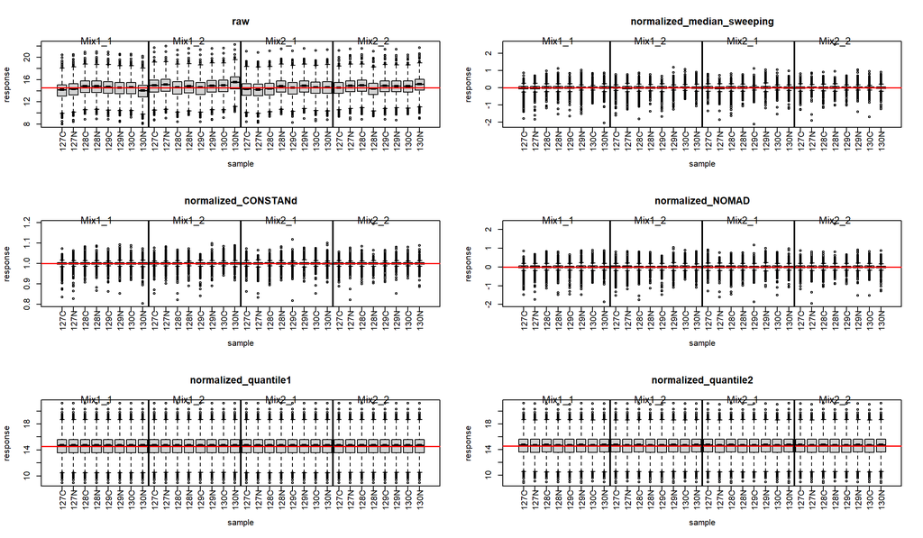

```r
# use (half-)wide format
par(mfrow=c(3,2))
boxplot_w(dat.nonnorm.summ.w,sample.info, 'raw')
for (i in 1:n.comp.variants){
  boxplot_w(dat.norm.summ.w[[variant.names[i]]], sample.info, paste('normalized', variant.names[i], sep='_'))}
```

## 5.2 MA plots

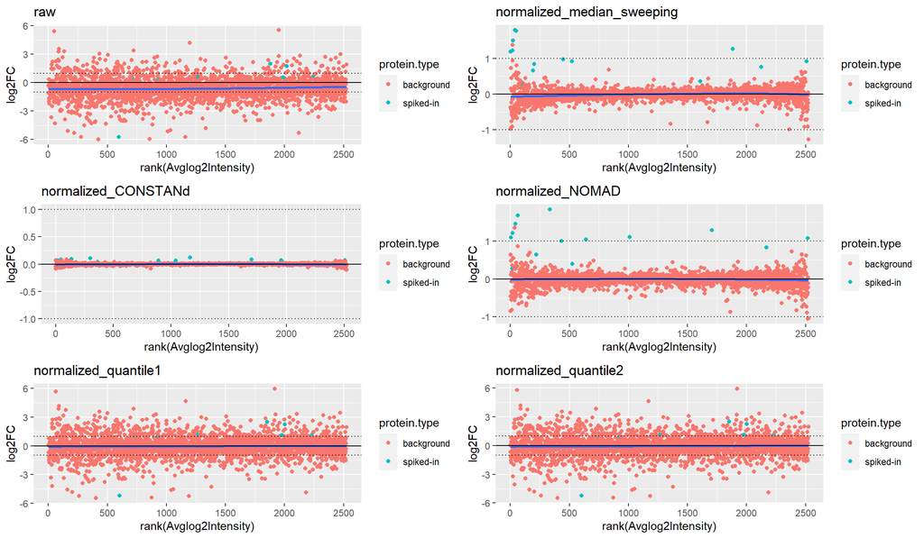

```r
# use wide2 format
p <- vector('list', n.comp.variants+1)
p[[1]] <- maplot_ils(dat.nonnorm.summ.w2, ma.onesample.num, ma.onesample.denom, scale.vec, 'raw', spiked.proteins)
for (i in 1: n.comp.variants){
 p[[i+1]]<- maplot_ils(dat.norm.summ.w2[[variant.names[i]]], ma.onesample.num, ma.onesample.denom, scale.vec, paste('normalized', variant.names[i], sep='_'), spiked.proteins)}
grid.arrange(grobs = p, ncol=2, nrow=3)
```

To increase the robustness of these results, let’s make some more MA plots, but now for all samples from condition 0.5 and condition 0.125 (quantification values averaged within condition). Indeed, even the raw, unnormalized data now show less variability. The two plots of quantile approaches are still near-indistinguishable.

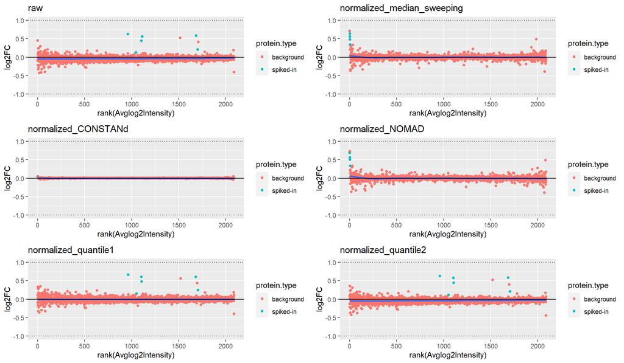

```r
channels.num <- sample.info %>% filter(Condition==ma.allsamples.num) %>% select(Sample) %>% pull
channels.denom <- sample.info %>% filter(Condition==ma.allsamples.denom) %>% select(Sample) %>% pull
p <- vector('list', n.comp.variants+1)
p[[1]] <- maplot_ils(dat.nonnorm.summ.w2, channels.num, channels.denom, scale.vec, 'raw', spiked.proteins)
for (i in 1: n.comp.variants){
 p[[i+1]]<- maplot_ils(dat.norm.summ.w2[[variant.names[i]]], channels.num, channels.denom, scale.vec, paste('normalized', variant.names[i], sep='_'), spiked.proteins)}
grid.arrange(grobs = p, ncol=2)
```

## 5.3 PCA plots

Now, let’s check if these multi-dimensional data contains some kind of grouping; It’s time to make PCA plots.

### 5.3.1 Using all proteins

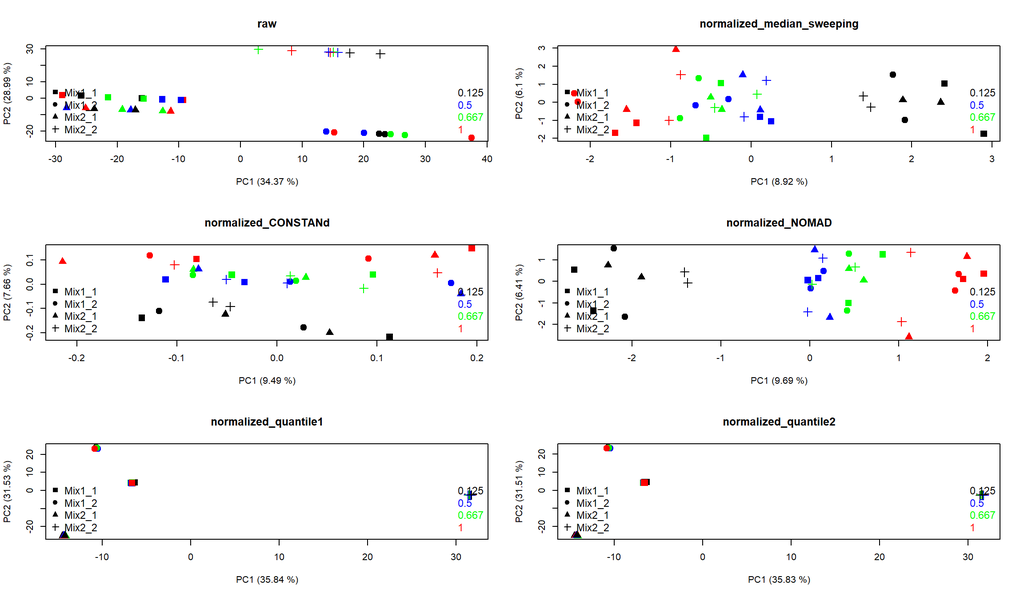

```r
par(mfrow=c(3,2))
pcaplot_ils(dat.nonnorm.summ.w2 %>% select(-'Protein'), info=sample.info, 'raw')
for (i in 1:n.comp.variants){
pcaplot_ils(dat.norm.summ.w2[[variant.names[i]]] %>% select(-'Protein'), info=sample.info, paste('normalized', variant.names[i], sep='_'))}
```

There are only 19 proteins supposed to be differentially expressed in this data set, which is only a very small amount in both relative (to the 4083 proteins total) and absolute (for a biological sample) terms.

### 5.3.2 Using spiked proteins only

Therefore, let’s see what the PCA plots look like if we were to only use the spiked proteins in the PCA. After normalization, the non-quantile variants produce similar plots where only conditions 0.5 and 0.667 aren’t clearly separable. The quantile approaches again barely change the variance structure of the raw data.

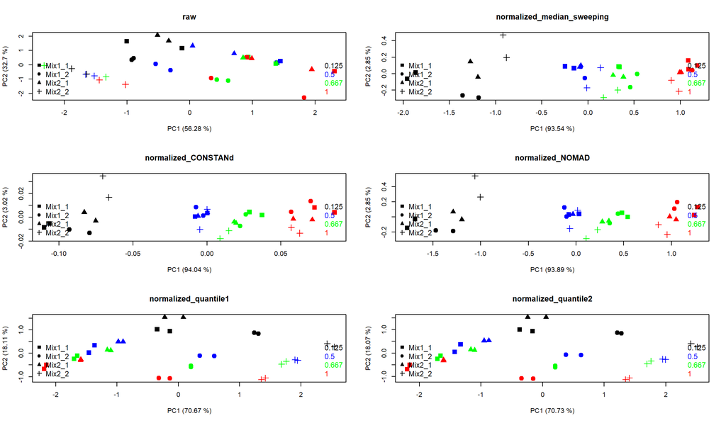

```r
par(mfrow=c(3,2))
pcaplot_ils(dat.nonnorm.summ.w2 %>% filter(Protein %in% spiked.proteins) %>% select(-'Protein'), info=sample.info, 'raw')
for (i in 1:n.comp.variants){
  pcaplot_ils(dat.norm.summ.w2[[variant.names[i]]] %>% filter(Protein %in% spiked.proteins) %>% select(-'Protein'), info=sample.info, paste('normalized', variant.names[i], sep='_'))}
```

Notice how for all PCA plots, the percentage of variance explained by PC1 is now much greater than when using data from all proteins. In a real situation without spiked proteins, you might plot data corresponding to the top X most differential proteins instead.

## 5.4 HC (hierarchical clustering) plots

The PCA plots of all proteins has a rather lower fraction of variance explained by PC1. We can confirm this using the hierarchical clustering dendrograms below: when considering the entire multidimensional space, the different conditions are not very separable at all (except for condition 0.125 after the non-quantile normalization approaches). This is not surprising as there is little biological variation between the conditions: there are only 19 truly differential proteins, and they all (ought to) covary in exactly the same manner (i.e., their variation can be captured in one dimension).

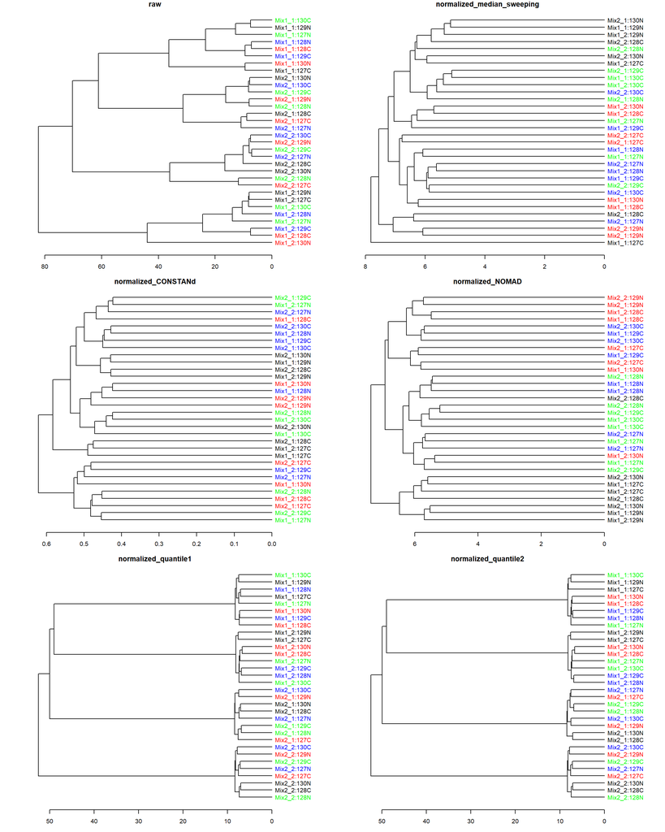

```r
par(mfrow=c(3,2))
dendrogram_ils(dat.nonnorm.summ.w2 %>% select(-Protein), info=sample.info, 'raw')
for (i in 1:n.comp.variants){
  dendrogram_ils(dat.norm.summ.w2[[variant.names[i]]] %>% select(-Protein), info=sample.info, paste('normalized', variant.names[i], sep='_'))}
```

## 5.5 Run effect p-value plot

Our last quality check involves a measure of how well each variant was able to assist in removing the run effect. Below are the distributions of p-values from a linear model for the `response` variable with `Run` as a covariate. If the run effect was removed successfully, these p-values ought to be large.

Clearly, the raw data contains a run effect, which is partially removed by median sweeping and as good as completely removed by CONSTANd and NOMAD. Both quantile approaches do not remove the run effect (their curves overlaps with the raw data curve).

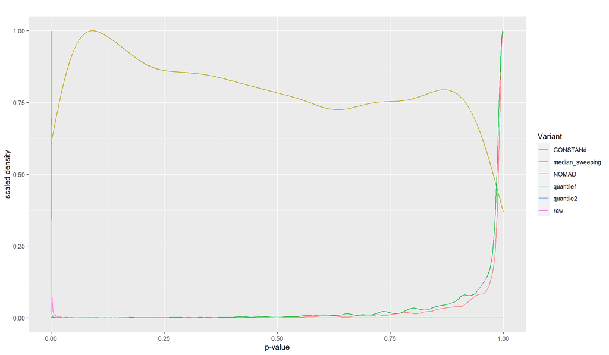

```r
dat <- vector('list',length(dat.norm.summ.l)+1)
dat[[1]] <- dat.nonnorm.summ.l; dat[2:length(dat)] <- dat.norm.summ.l[1:length(dat.norm.summ.l)]
names(dat) <- c('raw', names(dat.norm.summ.l))
run_effect_plot(dat)
```

# 6 DEA component: Moderated t-test

To check whether these fold changes are significant (criterium: $q<0.05$), we use a [moderated t-test](http://www.biostat.jhsph.edu/~kkammers/software/eupa/R_guide.html) slightly adapted from the `limma` package, which in use cases like ours should improve statistical power over a regular t-test. In a nutshell, this is a t-test done independently for each protein, although the variance used in the calculation of the t-statistic is [moderated using some empirical Bayes estimation](https://doi.org/10.2202/1544-6115.1027). After testing, we make a correction for multiple testing using the Benjamini-Hochberg method in order to keep the FDR under control.

```r
# design matrix as used in ANOVA testing.
design.matrix <- get_design_matrix(referenceCondition, sample.info)
dat.dea <- emptyList(names(dat.norm.summ.w2))
for (i in 1:n.comp.variants) {
  this_scale <- scale.vec
  d <- column_to_rownames(as.data.frame(dat.norm.summ.w2[[variant.names[i]]]), 'Protein')
  dat.dea[[variant.names[i]]] <- moderated_ttest(dat=d, design.matrix, scale=this_scale)}
# also see what the unnormalized results would look like
n.comp.variants <- n.comp.variants + 1
variant.names <- c(variant.names, 'raw')
dat.dea$raw <- moderated_ttest(dat=column_to_rownames(dat.nonnorm.summ.w2, 'Protein'), design.matrix, scale='log')
```

For each condition, we now get the fold changes, moderated and unmoderated p-values, moderated and unmoderated q-values (BH-adjusted p-values), and some other details (head of dataframe below).

```r
display_dataframe_head(dat.dea[[1]])
```

|  | logFC_0.125 | logFC_0.667 | logFC_1 | t.ord_0.125 | t.ord_0.667 | t.ord_1 | t.mod_0.125 | t.mod_0.667 | t.mod_1 | p.ord_0.125 | p.ord_0.667 | p.ord_1 | p.mod_0.125 | p.mod_0.667 | p.mod_1 | q.ord_0.125 | q.ord_0.667 | q.ord_1 | q.mod_0.125 | q.mod_0.667 | q.mod_1 | df.r | df.0 | s2.0 | s2 | s2.post |
| --- | --- | --- | --- | --- | --- | --- | --- | --- | --- | --- | --- | --- | --- | --- | --- | --- | --- | --- | --- | --- | --- | --- | --- | --- | --- | --- |
| A0AVT1 | -0.0296332 | -0.0190075 | 0.0086228 | -1.2236300 | -0.7848676 | 0.3560550 | -1.1698892 | -0.7503969 | 0.3404173 | 0.2312896 | 0.4391218 | 0.7244682 | 0.2512504 | 0.4588575 | 0.7359131 | 0.9569613 | 0.9960123 | 0.9898622 | 0.9350748 | 0.9805978 | 0.9840728 | 28 | 2.018963 | 0.0056242 | 0.0023459 | 0.0025664 |
| A0FGR8 | 0.0121287 | 0.0389655 | 0.0247813 | 0.3627376 | 1.1653597 | 0.7411452 | 0.3596350 | 1.1553923 | 0.7348061 | 0.7195248 | 0.2537054 | 0.4647764 | 0.7216378 | 0.2570437 | 0.4681594 | 0.9841943 | 0.9960123 | 0.9820911 | 0.9795638 | 0.9723943 | 0.9650451 | 28 | 2.018963 | 0.0056242 | 0.0044720 | 0.0045495 |
| A0MZ66 | 0.0035130 | -0.0009938 | -0.0183834 | 0.0761086 | -0.0215311 | -0.3982773 | 0.0769941 | -0.0217816 | -0.4029113 | 0.9398739 | 0.9829747 | 0.6934465 | 0.9391391 | 0.9827663 | 0.6898687 | 0.9978394 | 0.9975071 | 0.9898622 | 0.9964971 | 0.9975410 | 0.9825206 | 28 | 2.018963 | 0.0056242 | 0.0085220 | 0.0083271 |
| A1L0T0 | 0.0520381 | -0.0328378 | -0.0500166 | 0.7951963 | -0.5017969 | -0.7643056 | 0.8165216 | -0.5152539 | -0.7848025 | 0.4358354 | 0.6212896 | 0.4536089 | 0.4229483 | 0.6115101 | 0.4409319 | 0.9569613 | 0.9975071 | 0.9820911 | 0.9350748 | 0.9924981 | 0.9650451 | 20 | 2.018963 | 0.0056242 | 0.0128474 | 0.0121851 |
| A3KMH1 | 0.4342224 | 0.3206653 | 0.5484563 | 1.7510253 | 1.2931002 | 2.2116798 | 1.8344616 | 1.3547163 | 2.3170662 | 0.0952654 | 0.2107143 | 0.0387933 | 0.0801348 | 0.1892462 | 0.0301887 | 0.9569613 | 0.9960123 | 0.7960743 | 0.9350748 | 0.9540539 | 0.7680706 | 20 | 2.018963 | 0.0056242 | 0.1844849 | 0.1680848 |
| A4D1E9 | -0.0219254 | -0.0731552 | -0.0426655 | -0.4771987 | -1.5921945 | -0.9285977 | -0.4796669 | -1.6004298 | -0.9334006 | 0.6383938 | 0.1270236 | 0.3641701 | 0.6361944 | 0.1237544 | 0.3607366 | 0.9741019 | 0.9841938 | 0.9820911 | 0.9644451 | 0.9260254 | 0.9650451 | 20 | 2.018963 | 0.0056242 | 0.0063331 | 0.0062681 |

# 7 Results comparison

Now, the most important part: let’s find out how our component variants have affected the outcome of the DEA.

## 7.1 Confusion matrix

A confusion matrix shows how many true and false positives/negatives each variant has given rise to. Spiked proteins that are DE are true positives, background proteins that are not DE are true negatives. We calculate this matrix for all conditions and then calculate some other informative metrics based on the confusion matrices: accuracy, sensitivity, specificity, positive predictive value and negative predictive value.

Clearly, across the board, the quantile normalization approaches underperform while median sweeping, CONSTANd and NOMAD are on equal footing, with an acceptable but not spectacular sensitivity. That said, the contrast between conditions 0.667 and 0.5 seems not large enough to yield many significant results.

```r
cm <- conf_mat(dat.dea, 'q.mod', 0.05, spiked.proteins)
print_conf_mat(cm, referenceCondition)
```

|  | 0.125 vs 0.5 contrast median_sweeping background | 0.125 vs 0.5 contrast median_sweeping spiked | 0.125 vs 0.5 contrast CONSTANd background | 0.125 vs 0.5 contrast CONSTANd spiked | 0.125 vs 0.5 contrast NOMAD background | 0.125 vs 0.5 contrast NOMAD spiked | 0.125 vs 0.5 contrast quantile1 background | 0.125 vs 0.5 contrast quantile1 spiked | 0.125 vs 0.5 contrast quantile2 background | 0.125 vs 0.5 contrast quantile2 spiked | 0.125 vs 0.5 contrast raw background | 0.125 vs 0.5 contrast raw spiked |
| --- | --- | --- | --- | --- | --- | --- | --- | --- | --- | --- | --- | --- |
| not_DE | 4061 | 4 | 4060 | 4 | 4062 | 4 | 4064 | 15 | 4064 | 15 | 4064 | 19 |
| DE | 3 | 15 | 4 | 15 | 2 | 15 | 0 | 4 | 0 | 4 | 0 | 0 |

|  | 0.125 vs 0.5 contrast median_sweeping | 0.125 vs 0.5 contrast CONSTANd | 0.125 vs 0.5 contrast NOMAD | 0.125 vs 0.5 contrast quantile1 | 0.125 vs 0.5 contrast quantile2 | 0.125 vs 0.5 contrast raw |
| --- | --- | --- | --- | --- | --- | --- |
| Accuracy | 0.998 | 0.998 | 0.999 | 0.996 | 0.996 | 0.995 |
| Sensitivity | 0.789 | 0.789 | 0.789 | 0.211 | 0.211 | 0.000 |
| Specificity | 0.999 | 0.999 | 1.000 | 1.000 | 1.000 | 1.000 |
| PPV | 0.833 | 0.789 | 0.882 | 1.000 | 1.000 | NaN |
| NPV | 0.999 | 0.999 | 0.999 | 0.996 | 0.996 | 0.995 |

|  | 0.667 vs 0.5 contrast median_sweeping background | 0.667 vs 0.5 contrast median_sweeping spiked | 0.667 vs 0.5 contrast CONSTANd background | 0.667 vs 0.5 contrast CONSTANd spiked | 0.667 vs 0.5 contrast NOMAD background | 0.667 vs 0.5 contrast NOMAD spiked | 0.667 vs 0.5 contrast quantile1 background | 0.667 vs 0.5 contrast quantile1 spiked | 0.667 vs 0.5 contrast quantile2 background | 0.667 vs 0.5 contrast quantile2 spiked | 0.667 vs 0.5 contrast raw background | 0.667 vs 0.5 contrast raw spiked |
| --- | --- | --- | --- | --- | --- | --- | --- | --- | --- | --- | --- | --- |
| not_DE | 4064 | 18 | 4064 | 18 | 4064 | 17 | 4064 | 19 | 4064 | 19 | 4064 | 19 |
| DE | 0 | 1 | 0 | 1 | 0 | 2 | 0 | 0 | 0 | 0 | 0 | 0 |

|  | 0.667 vs 0.5 contrast median_sweeping | 0.667 vs 0.5 contrast CONSTANd | 0.667 vs 0.5 contrast NOMAD | 0.667 vs 0.5 contrast quantile1 | 0.667 vs 0.5 contrast quantile2 | 0.667 vs 0.5 contrast raw |
| --- | --- | --- | --- | --- | --- | --- |
| Accuracy | 0.996 | 0.996 | 0.996 | 0.995 | 0.995 | 0.995 |
| Sensitivity | 0.053 | 0.053 | 0.105 | 0.000 | 0.000 | 0.000 |
| Specificity | 1.000 | 1.000 | 1.000 | 1.000 | 1.000 | 1.000 |
| PPV | 1.000 | 1.000 | 1.000 | NaN | NaN | NaN |
| NPV | 0.996 | 0.996 | 0.996 | 0.995 | 0.995 | 0.995 |

|  | 1 vs 0.5 contrast median_sweeping background | 1 vs 0.5 contrast median_sweeping spiked | 1 vs 0.5 contrast CONSTANd background | 1 vs 0.5 contrast CONSTANd spiked | 1 vs 0.5 contrast NOMAD background | 1 vs 0.5 contrast NOMAD spiked | 1 vs 0.5 contrast quantile1 background | 1 vs 0.5 contrast quantile1 spiked | 1 vs 0.5 contrast quantile2 background | 1 vs 0.5 contrast quantile2 spiked | 1 vs 0.5 contrast raw background | 1 vs 0.5 contrast raw spiked |
| --- | --- | --- | --- | --- | --- | --- | --- | --- | --- | --- | --- | --- |
| not_DE | 4060 | 5 | 4062 | 5 | 4062 | 5 | 4064 | 16 | 4064 | 15 | 4064 | 19 |
| DE | 4 | 14 | 2 | 14 | 2 | 14 | 0 | 3 | 0 | 4 | 0 | 0 |

|  | 1 vs 0.5 contrast median_sweeping | 1 vs 0.5 contrast CONSTANd | 1 vs 0.5 contrast NOMAD | 1 vs 0.5 contrast quantile1 | 1 vs 0.5 contrast quantile2 | 1 vs 0.5 contrast raw |
| --- | --- | --- | --- | --- | --- | --- |
| Accuracy | 0.998 | 0.998 | 0.998 | 0.996 | 0.996 | 0.995 |
| Sensitivity | 0.737 | 0.737 | 0.737 | 0.158 | 0.211 | 0.000 |
| Specificity | 0.999 | 1.000 | 1.000 | 1.000 | 1.000 | 1.000 |
| PPV | 0.778 | 0.875 | 0.875 | 1.000 | 1.000 | NaN |
| NPV | 0.999 | 0.999 | 0.999 | 0.996 | 0.996 | 0.995 |

## 7.2 Correlation scatter plots

To see whether the three normalization methods produce similar results on the detailed level of individual proteins, we make scatter plots and check the correlation between their fold changes and between their significance estimates (q-values, in our case).

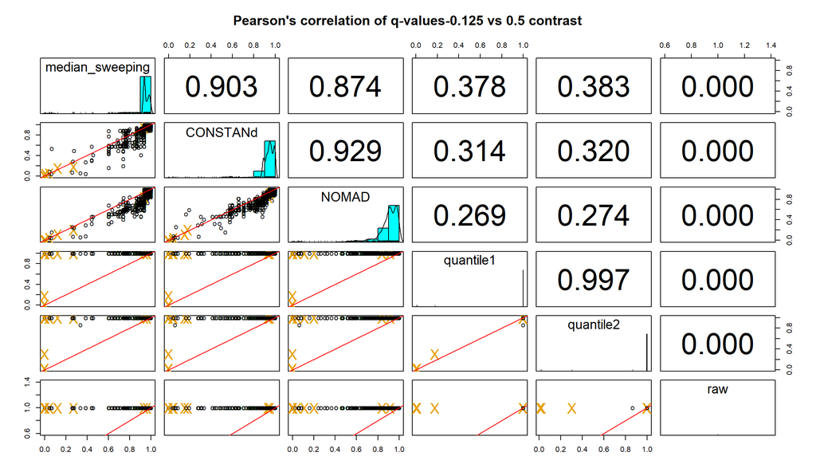

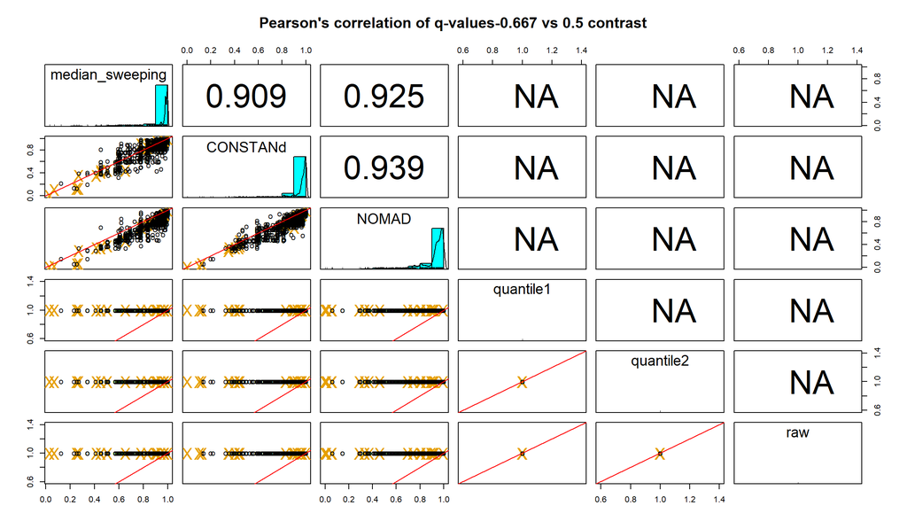

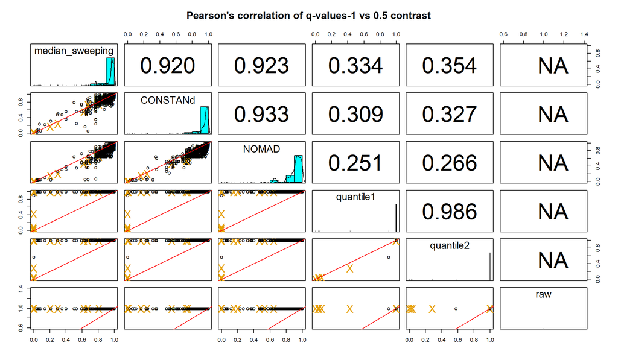

```r
scatterplot_ils(dat.dea, significance.cols, 'q-values', spiked.proteins, referenceCondition)
```

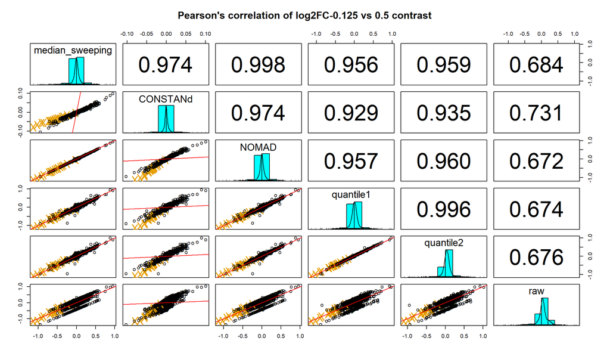

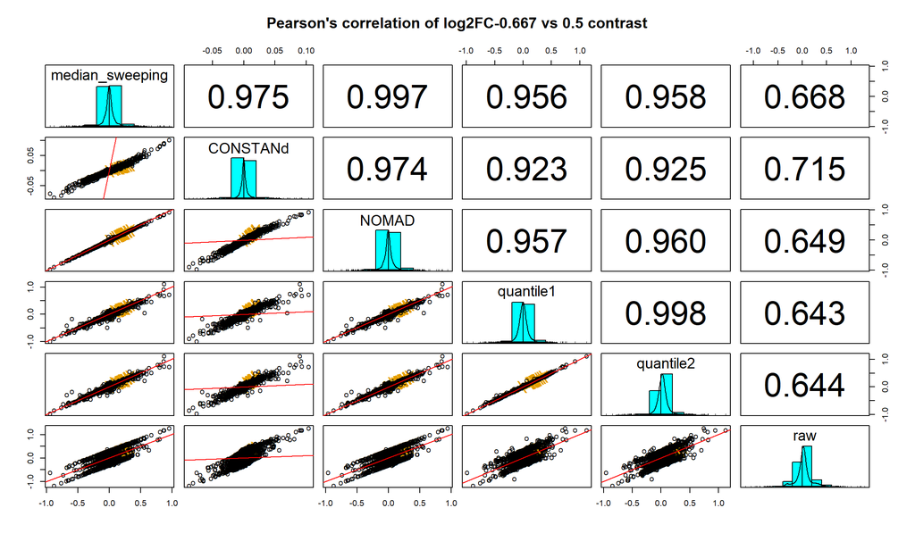

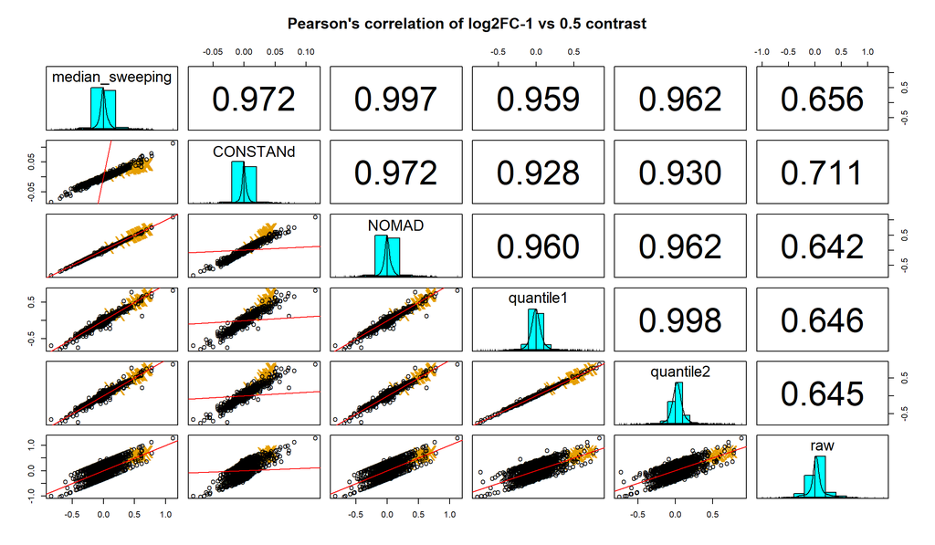

```r
scatterplot_ils(dat.dea, logFC.cols, 'log2FC', spiked.proteins, referenceCondition)
```

## 7.3 Volcano plots

The volcano plot combines information on fold changes and statistical significance. The spike-in proteins are colored blue, and immediately it is clear that their fold changes dominate the region of statistical significance, which suggests the experiment and analysis were carried out successfully. The magenta, dashed line indicates the theoretical fold change of the spike-ins.

The quantile plots are extremely flat, suggesting the approach is not powerufl enough. We can again see how CONSTANd fold changes are disproportionately low in absolute value.

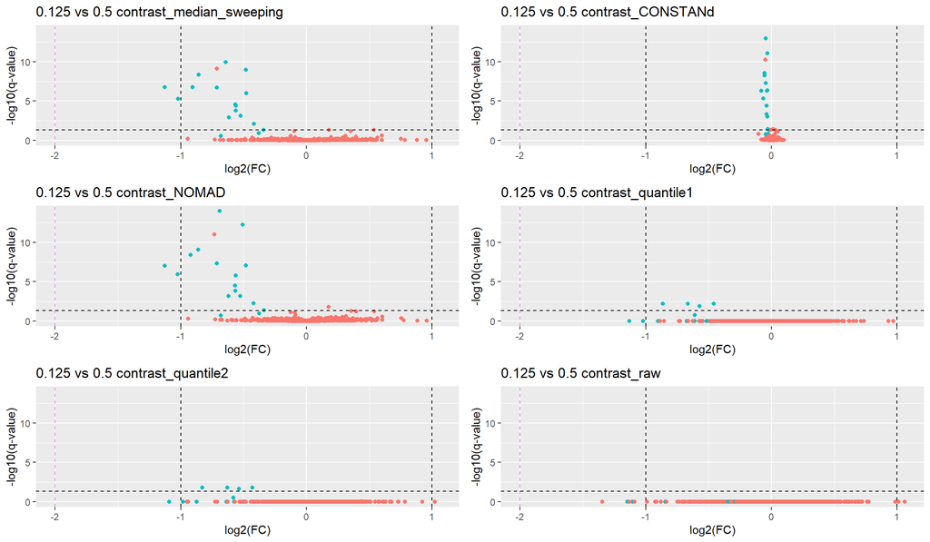

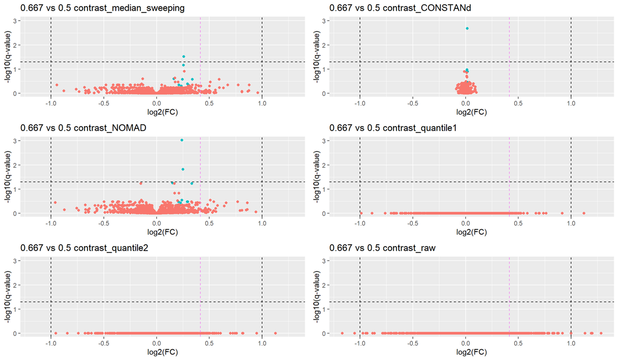

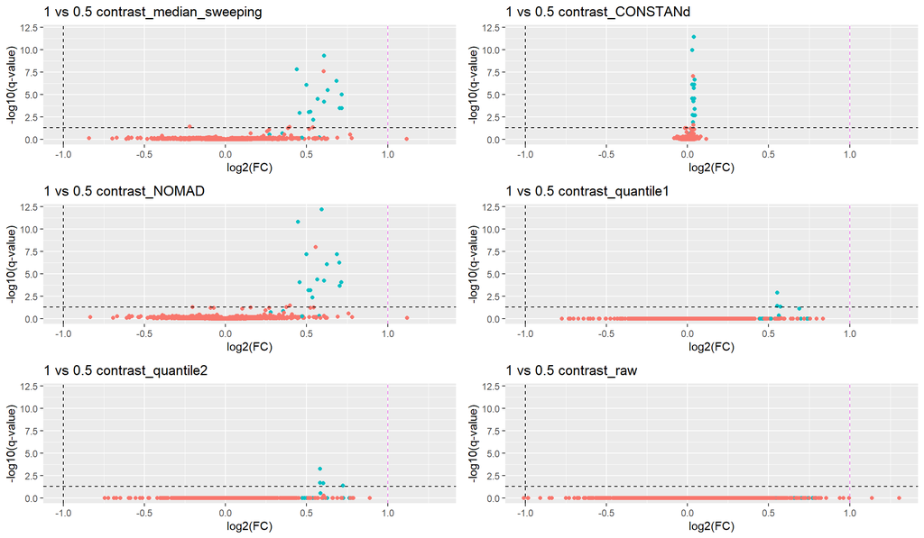

```r
for (i in 1:n.contrasts){
  volcanoplot_ils(dat.dea, i, spiked.proteins, referenceCondition)}
```

## 7.4 Violin plots

A good way to assess the general trend of the fold change estimates on a more ‘macroscopic’ scale is to make a violin plot. Ideally, there will be some spike-in proteins that attain the expected fold change (red dashed line) that corresponds to their condition, while most (background) protein log2 fold changes are situated around zero.

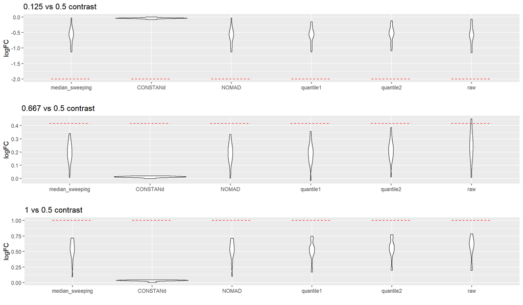

```r
# plot theoretical value (horizontal lines) and violin per variant
if (length(spiked.proteins)>0) violinplot_ils(lapply(dat.dea, function(x) x[spiked.proteins, logFC.cols]), referenceCondition) else violinplot_ils(lapply(dat.dea, function(x) x[,logFC.cols]), referenceCondition,  show_truth = FALSE)
```

# 8 Conclusions

For the given data set, the differences in proteomic outcomes between median sweeping and NOMAD normalization are quite small, both on the global and individual scale. The quantile methods seem to underperform across the board, but they still produce reliable fold change estimates. Finally, CONSTANd naturally reduces the variance in the distribution of quantification values and is only suitable for use with untransformed intensities. When used on log2-transformed values like we did here, there is a double variance-reducing effect that ends up over-compressing the fold change estimates. However, when applied to untransformed intensities like in this bonus notebook, the CONSTANd method performs at least on par with median sweeping!